# DS6371 Kaggle Project

Christopher Dawson, Matt Farrow

8/1/2020

## Introduction

“Ask a home buyer to describe their dream house, and they probably won’t begin with the height of the basement ceiling or the proximity to an east-west railroad. But this playground competition’s dataset proves that much more influences price negotiations than the number of bedrooms or a white-picket fence.” ([Kaggle](https://www.kaggle.com/c/house-prices-advanced-regression-techniques/overview))

### Data Description

The [Ames Housing dataset](http://jse.amstat.org/v19n3/decock.pdf) was compiled by Dean De Cock and describes residential property sales in Ames, Iowa from 2006 to 2010. “The data set contains 2930 observations and a large number of explanatory variables (23 nominal, 23 ordinal, 14 discrete, and 20 continuous) involved in assessing home values.” [^1]

[Full data description](http://jse.amstat.org/v19n3/decock/DataDocumentation.txt)

## Analysis Question 1

### Restatement of Problem

Century 21 Ames, a real estate company in Ames, Iowa, has commissioned us to estimate how the sales price of a house in the North Ames (NAmes), Edwards, and Brookside (BrkSide) neighborhoods is related to the square footage (GrLivArea) of the house and if the sales price and its relationship to square footage depends on which neighborhood the house is located in.

### Build and Fit the Model

In assessing the data, the original training dataset has been filtered down to only the neighborhoods of interest. It appears that a linear relationship exists between square footage and sale price, although a number of outliers are also present. However, the log-log transformed data appeared to be a more appropriate fit for the data, so we proceeded using that transformation. (figure 1)

Based on the problem, our model for the relationship between square footage and sale price is:

$median(log\_sale\_price) = b_o + b_1(log\_sq\_foot) + b_2(Edwards) + b_3(NAmes) + b_4(log\_sq\_foot*Edwards) + b_5(log\_sq\_foot*NAmes)$

```
##
## Call:
## lm(formula = log_sale_price ~ log_sq_foot + neighborhood + log_sq_foot *
##     neighborhood, data = train_by_neighborhood)
##
## Residuals:
##      Min       1Q   Median       3Q      Max
## -0.73040 -0.10050  0.01414  0.10769  0.80516
##
## Coefficients:
##                                 Estimate Std. Error t value Pr(>|t|)
## (Intercept)                      6.00682    0.48909  12.282  < 2e-16 ***
## log_sq_foot                      0.80662    0.06945  11.614  < 2e-16 ***
## neighborhoodEdwards              2.02615    0.63222   3.205 0.001467 **
## neighborhoodNAmes                2.40649    0.58754   4.096 5.15e-05 ***
## log_sq_foot:neighborhoodEdwards -0.29066    0.08929  -3.255 0.001235 **
## log_sq_foot:neighborhoodNAmes   -0.32260    0.08307  -3.883 0.000122 ***
## ---
## Signif. codes:  0 '***' 0.001 '**' 0.01 '*' 0.05 '.' 0.1 ' ' 1
##
## Residual standard error: 0.1912 on 377 degrees of freedom
## Multiple R-squared:  0.5177, Adjusted R-squared:  0.5113
## F-statistic: 80.94 on 5 and 377 DF,  p-value: < 2.2e-16
```

The results of the linear model indicate that our final model for the North Ames, Edwards, and Brookside neighborhoods is as follows:

The full model can be simplified by neighborhood:

- $median(log\_sale\_price | log\_sq\_foot, neighborhood = NAmes) = (b_o + b_3) + (b_1 + b_5)log\_sq\_foot$
- $median(log\_sale\_price | log\_sq\_foot, neighborhood = Edwards) = (b_o + b_2) + (b_1 + b_4)log\_sq\_foot$
- $median(log\_sale\_price | log\_sq\_foot, neighborhood = BrkSide) = b_o + b_1(log\_sq\_foot)$

### Checking Assumptions

#### Residual Plots (Log-Transformed Data)

(figure 2)

1. **Linearity**: The plots of residuals and studentized residuals, although primarily clustered around 11.5-12.0, do appear as a random cloud.
2. **Normality**: The histogram shows the residuals to be fairly normally distributed.
3. **Equal Standard Deviation**: The Q-Q plot shows the residuals to be linearly distributed.
4. **Outliers**: There are a handful of outliers that we decided to include in this model.

The assumptions for using the log-log transformation model have been met and we proceeded with our analysis.

#### Influential Point Analysis

Based on the Cook’s D plot (figure 3), most of the data is relatively clumped together, however there is a single outlier that should be explored further.

## Analysis Question 2

### Restatement of Problem

Build a predictive model for sales prices of all residential property sales in Ames, Iowa using multiple linear regression to analyze all of the variables in the dataset. In addition to building a custom model, we will also include three additional models: forward selection, backwards elimination, and stepwise selection. Finally, we will compare the Adjusted R-squared, CV Press, and Kaggle scores for each of the models to determine which offers the most accurate prediction of future home sales in Ames, Iowa.

## Appendix

### Figures

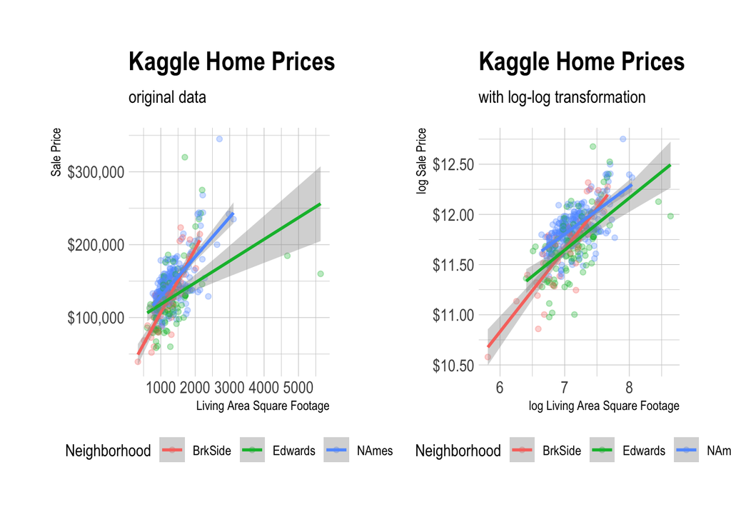

Figure 1: Square footage and sales price, original and log-log transformed.

Table 1: 95% confidence intervals for log-log transformed model in Question 1

|  | 2.5 % | 97.5 % |
| --- | --- | --- |
| (Intercept) | 5.0451379 | 6.9684954 |
| log_sq_foot | 0.6700618 | 0.9431802 |
| neighborhoodEdwards | 0.7830359 | 3.2692553 |
| neighborhoodNAmes | 1.2512203 | 3.5617511 |
| log_sq_foot:neighborhoodEdwards | -0.4662196 | -0.1150910 |
| log_sq_foot:neighborhoodNAmes | -0.4859422 | -0.1592606 |

Table 2: ANOVA of log-log transformed full model in Question 1

|  | Df | Sum Sq | Mean Sq | F value | Pr(>F) |
| --- | --- | --- | --- | --- | --- |
| log_sq_foot | 1 | 12.2728734 | 12.2728734 | 335.840499 | 0.0000000 |
| neighborhood | 2 | 1.9316040 | 0.9658020 | 26.428646 | 0.0000000 |
| log_sq_foot:neighborhood | 2 | 0.5848523 | 0.2924261 | 8.002082 | 0.0003949 |
| Residuals | 377 | 13.7769962 | 0.0365438 | NA | NA |

Table 3: ANOVA of log-log transformed reduced model in Question 1

|  | Df | Sum Sq | Mean Sq | F value | Pr(>F) |
| --- | --- | --- | --- | --- | --- |
| log_sq_foot | 1 | 12.272873 | 12.2728734 | 323.8733 | 0 |
| neighborhood | 2 | 1.931604 | 0.9658020 | 25.4869 | 0 |
| Residuals | 379 | 14.361849 | 0.0378941 | NA | NA |

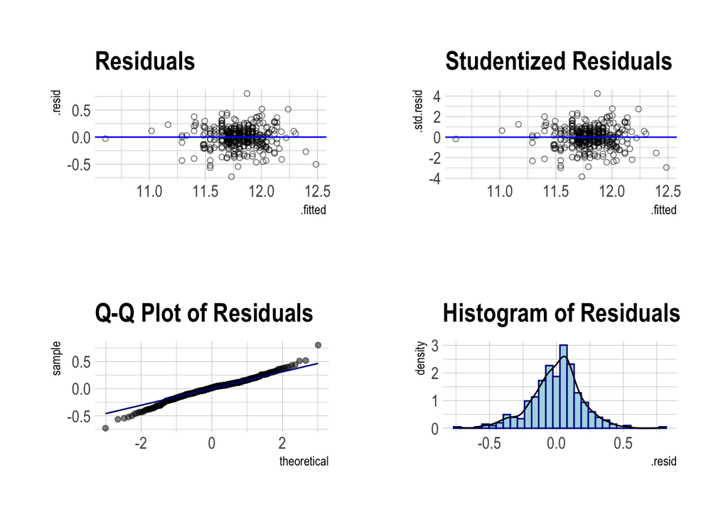

Figure 2: Log-log transformed data residuals

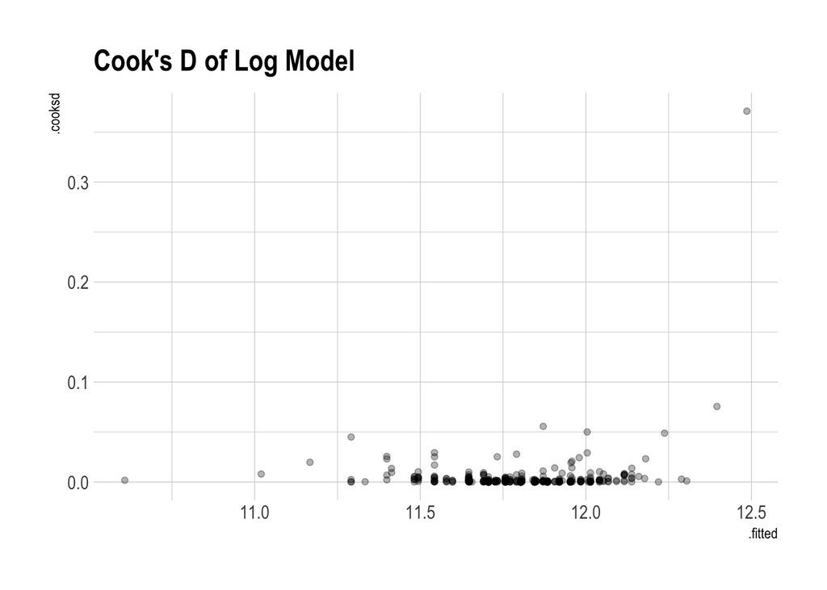

### References

### Q1: Full Code

```r
# Setup--------------------------------------------------------------------

# Load libraries
library(tidyverse)
library(hrbrthemes)   # clean plotting theme
library(scales)       # format scales
library(patchwork)    # organizing plots
library(broom)        # for working with model
library(bookdown)     # for working with captions & references
library(knitr)        # for table formatting
library(xtable)       # for exporting model results

# Load data
test <- read_csv("test.csv")
train <- read_csv("train.csv")

# Clean up column names
test <- janitor::clean_names(test)
train <- janitor::clean_names((train))

# Q1: Initial Scatter Plots------------------------------------------------

# Original data scatter plot
a <- train %>%
  filter(neighborhood %in% c("NAmes", "Edwards", "BrkSide")) %>%
  ggplot(aes(gr_liv_area, sale_price, color = neighborhood)) +
  geom_point(alpha = 0.3) +
  geom_smooth(method = "lm") +
  scale_y_continuous(label = dollar) +
  labs(title = "Kaggle Home Prices",
       subtitle = "original data",
       x = "Living Area Square Footage",
       y = "Sale Price",
       color = "Neighborhood") +
  theme_ipsum() +
  theme(legend.position = "bottom") +
  NULL

# Log-log data scatter plot
b <- train %>%
  filter(neighborhood %in% c("NAmes", "Edwards", "BrkSide")) %>%
  ggplot(aes(log(gr_liv_area), log(sale_price), color = neighborhood)) +
  geom_point(alpha = 0.3) +
  geom_smooth(method = "lm") +
  scale_y_continuous(label = dollar) +
  labs(title = "Kaggle Home Prices",
       subtitle = "with log-log transformation",
       x = "log Living Area Square Footage",
       y = "log Sale Price",
       color = "Neighborhood") +
  theme_ipsum() +
  theme(legend.position = "bottom") +
  NULL

# Patchwork layout
a + b

# Q1: Model Construction---------------------------------------------------

# Filter training set
train_by_neighborhood <- train %>%
  filter(neighborhood %in% c("NAmes", "Edwards", "BrkSide")) %>%
  mutate(sq_foot = round(gr_liv_area, digits = -2),
         log_sq_foot = log(sq_foot),
         log_sale_price = log(sale_price)) %>%
  select(id, sq_foot, log_sq_foot,  neighborhood, sale_price, log_sale_price)

# Identify outliers
outliers <- boxplot(train_by_neighborhood$log_sale_price, plot = FALSE)$out
train_by_neighborhood_outliers <- train_by_neighborhood %>%
  filter(!log_sale_price %in% outliers)

# Create models
log_model <- lm(log_sale_price ~
                  log_sq_foot +
                  neighborhood +
                  log_sq_foot*neighborhood,
                data = train_by_neighborhood)

log_model_reduced <- lm(log_sale_price ~
                          log_sq_foot +
                          neighborhood)

# Full model statistics
summary(log_model)  # summary statistics
confint(log_model)  # confidence intervals
anova(log_model)    # ANOVA

# Reduced model statistics
anova(log_model_reduced)  # ANOVA

# Q1: Plot Residuals-------------------------------------------------------

# Plot residuals
a <- log_model %>%
  ggplot(aes(.fitted, .resid)) +
  geom_point(shape = 1, alpha = 0.5) +
  geom_hline(yintercept = 0, color = "blue") +
  labs(title = "Residuals") +
  theme_ipsum()

# Plot studentized residuals
b <- log_model %>%
  augment() %>%
  ggplot(aes(.fitted, .std.resid)) +
  geom_point(shape = 1, alpha = 0.5) +
  geom_hline(yintercept = 0, color = "blue") +
  labs(title = "Studentized Residuals") +
  theme_ipsum()

# Q-Q Plot of Residuals
c <- log_model %>%
  ggplot(aes(sample = .resid)) +
  stat_qq(alpha = 0.5) +
  stat_qq_line(color = "darkblue") +
  labs(title = "Q-Q Plot of Residuals") +
  theme_ipsum()

# Histogram of residuals
d <- log_model %>%
  ggplot(aes(.resid, ..density..)) +
  geom_histogram(fill = "lightblue", color = "darkblue") +
  geom_density() +
  labs(title = "Histogram of Residuals") +
  theme_ipsum()

# Assemble plots using patchwork
(a + b) / (c + d)

# Q1: Cook's D-------------------------------------------------------------
log_model %>%
  augment() %>%
  ggplot(aes(.fitted, .cooksd)) +
  geom_jitter(alpha = 0.3) +
  labs(title = "Cook's D of Log Model") +
  theme_ipsum()
```

[^1]: Dean De Cock, “Ames, Iowa: Alternative to the Boston Housing Data as an End of Semester Regression Project”, Journal of Statistics Education, Volume 19, Number 3(2011).